# Analysis of Events most Detrimental to Health and Economic Well-Being

Jessica

May 23, 2015

## Synopsis

An analysis was performed of the U.S. National Oceanic and Atmospheric Administration’s (NOAA) storm database. This database tracks characteristics of major storms and weather events in the United States, including when and where they occur, as well as estimates of any fatalities, injuries, and property damage. Tornadoes were found to be the most harmful events for population health, causing the most injuries and fatalities of any type of event. Tornadoes were also found to be the events most detrimental to economic well-being, causing the most combined property and crop damage.

### Data Processing

The data was downloaded and read into R.

```r
download.file("https://d396qusza40orc.cloudfront.net/repdata%2Fdata%2FStormData.csv.bz2",
              destfile="stormdata.csv.bz2", method="curl")
rawdata <- read.csv("stormdata.csv.bz2")
names(rawdata)
```

```
##  [1] "STATE__"    "BGN_DATE"   "BGN_TIME"   "TIME_ZONE"  "COUNTY"
##  [6] "COUNTYNAME" "STATE"      "EVTYPE"     "BGN_RANGE"  "BGN_AZI"
## [11] "BGN_LOCATI" "END_DATE"   "END_TIME"   "COUNTY_END" "COUNTYENDN"
## [16] "END_RANGE"  "END_AZI"    "END_LOCATI" "LENGTH"     "WIDTH"
## [21] "F"          "MAG"        "FATALITIES" "INJURIES"   "PROPDMG"
## [26] "PROPDMGEXP" "CROPDMG"    "CROPDMGEXP" "WFO"        "STATEOFFIC"
## [31] "ZONENAMES"  "LATITUDE"   "LONGITUDE"  "LATITUDE_E" "LONGITUDE_"
## [36] "REMARKS"    "REFNUM"
```

All libraries necessary for analysis were loaded.

```r
# Load libraries
library(dplyr)
library(reshape2)
library(ggplot2)
library(scales)
```

## Results

### Most Harmful Events with respect to Population Health

The events most harmful with respect to population health are those that cause the greatest number of fatalities and injuries, as recorded in the “FATALITIES” and “INJURIES” columns of the data set.

```r
# Calculate total number of fatalities and injuries caused by each type of event.
pophealth <- rawdata %>% select(EVTYPE, FATALITIES, INJURIES) %>%
                         group_by(EVTYPE) %>%
                         summarise(fatalities=sum(FATALITIES), injuries=sum(INJURIES)) %>%
                         filter(fatalities + injuries > 0) %>%
                         arrange(desc(fatalities), desc(injuries))
head(pophealth)
```

```
## Source: local data frame [6 x 3]
##
##           EVTYPE fatalities injuries
## 1        TORNADO       5633    91346
## 2 EXCESSIVE HEAT       1903     6525
## 3    FLASH FLOOD        978     1777
## 4           HEAT        937     2100
## 5      LIGHTNING        816     5230
## 6      TSTM WIND        504     6957
```

It was confirmed that tornadoes are the most dangerous in all categories, causing the largest number of fatalities, the largest number of injuries, and the largest number of combined fatalities and injuries. Excessive heat causes the second-largest number of fatalities, and the second-largest number of combined fatalities and injuries.

```r
tornadorow <- pophealth[1,]
c(max(pophealth$fatalities)==tornadorow$fatalities,
  max(pophealth$injuries)==tornadorow$injuries,
  (max(pophealth$fatalities + pophealth$injuries)==tornadorow$fatalities+tornadorow$injuries))
```

```
## [1] TRUE TRUE TRUE
```

```r
head(pophealth %>% arrange(desc(fatalities+injuries)))
```

```
## Source: local data frame [6 x 3]
##
##           EVTYPE fatalities injuries
## 1        TORNADO       5633    91346
## 2 EXCESSIVE HEAT       1903     6525
## 3      TSTM WIND        504     6957
## 4          FLOOD        470     6789
## 5      LIGHTNING        816     5230
## 6           HEAT        937     2100
```

The plot below shows the number of injuries and fatalities caused by the six most dangerous types of events.

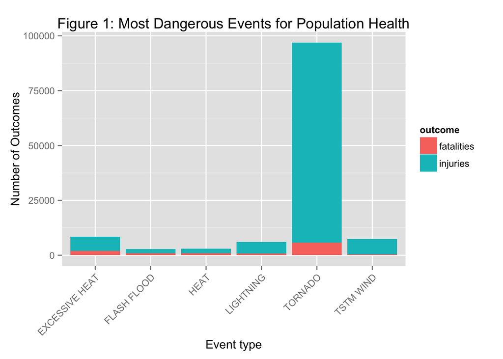

```r
# rearrange data frame so we can plot it
melted_pophealth <- melt(head(pophealth), id="EVTYPE")
names(melted_pophealth) <- c("EVTYPE", "outcome", "count")

ggplot(melted_pophealth, aes(EVTYPE, count)) +
    geom_bar(stat="identity", aes(fill=outcome),) +
    labs(title="Figure 1: Most Dangerous Events for Population Health", x="Event type",
         y="Number of Outcomes") +
    theme(axis.text.x = element_text(angle = 45, hjust = 1))
```

We conclude that tornadoes are the biggest threat to population health, with excessive heat the next most dangerous type of event.

### Events with Greatest Economic Consequences

The events which have the greatest economic consequences are those that cause the most property damage and crop damage, as recorded in the columns PROPDMG and CROPDMG of the storm data set.

```r
# Calculate total amount of property and crop damage caused by each type of event.
economicdamage <- rawdata %>% select(EVTYPE, PROPDMG, CROPDMG) %>%
                              group_by(EVTYPE) %>%
                              summarise(propdmg=sum(PROPDMG), cropdmg=sum(CROPDMG)) %>%
                              filter(propdmg + cropdmg > 0) %>%
                              arrange(desc(propdmg), desc(cropdmg))
head(economicdamage)
```

```
## Source: local data frame [6 x 3]
##
##              EVTYPE   propdmg   cropdmg
## 1           TORNADO 3212258.2 100018.52
## 2       FLASH FLOOD 1420124.6 179200.46
## 3         TSTM WIND 1335965.6 109202.60
## 4             FLOOD  899938.5 168037.88
## 5 THUNDERSTORM WIND  876844.2  66791.45
## 6              HAIL  688693.4 579596.28
```

```r
bycropdamage <- economicdamage %>% arrange(desc(cropdmg), desc(propdmg))
head(bycropdamage)
```

```
## Source: local data frame [6 x 3]
##
##              EVTYPE   propdmg   cropdmg
## 1              HAIL  688693.4 579596.28
## 2       FLASH FLOOD 1420124.6 179200.46
## 3             FLOOD  899938.5 168037.88
## 4         TSTM WIND 1335965.6 109202.60
## 5           TORNADO 3212258.2 100018.52
## 6 THUNDERSTORM WIND  876844.2  66791.45
```

Whether sorted by property damage or crop damage, the top six event types are the same. The figure below shows the property and crop damage caused by the six types of events that cause the most property and crop damage.

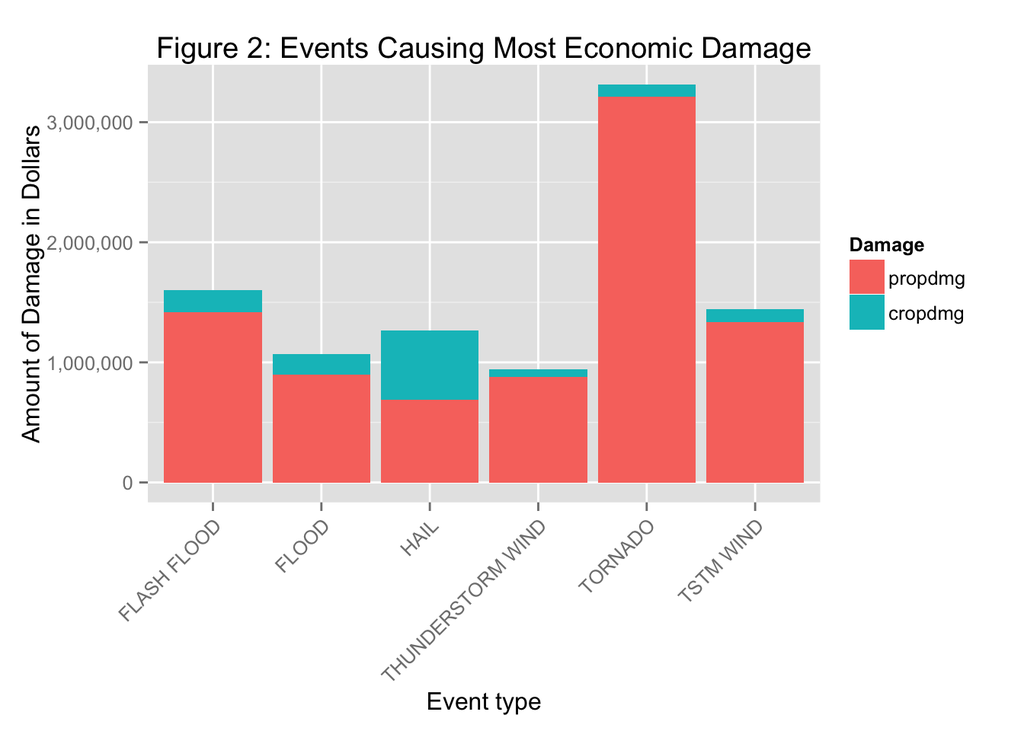

```r
# rearrange data frame so we can plot it
melted_econ <- melt(head(economicdamage), id="EVTYPE")
names(melted_econ) <- c("EVTYPE", "Damage", "count")

ggplot(melted_econ, aes(EVTYPE, count)) +
    geom_bar(stat="identity", aes(fill=Damage),) +
    labs(title="Figure 2: Events Causing Most Economic Damage", x="Event type",
         y="Amount of Damage in Dollars") +
    scale_y_continuous(labels=comma) +
    theme(axis.text.x = element_text(angle = 45, hjust = 1))
```

We conclude that hail causes the most crop damage, while tornadoes cause the most property damage and the most combined crop and property damage.

## Future Work

This is not a very good analysis. It would probably be a better idea to take fatalities per year, and property damage per year, caused by various types of events. However, we believe this analysis to be sufficient for the purpose of practicing writing reproducible reports.